# MC Summary

Lacey Etzkorn

October 18, 2016

First, we assume that the posting histories of each user are a Poisson Process, and so times between posts are exponentially distributed with some mean. For each individual, we can say that individual’s mean time between posts has prior distribution $\mu_i \sim gamma(1,1)$. This means that the user-specific posteriors for mean times between posts is given by $\mu_i|n,\bar{\epsilon} \sim gamma(1 + n, 1 + n\cdot\bar{\epsilon})$, where n is the user-specific number of intervals between posts, and $\bar{\epsilon}$ is the user-specific average time between posts. Note that when the user only has one post, their posterior distribution is simply the prior $\mu_i \sim gamma(1,1)$.

First we can simulate $mu_i$ given the data. The plot below represents the population distribution for $E(\mu_i |n,\bar{\epsilon})$.

```r
### Simulate Mu given Data
      alpha = 1; beta = 1
      mu = replicate(n = 10000, rgamma(N, shape = alpha + n, rate = beta + n*eps))
      dim(mu)
```

```
## [1]   489 10000
```

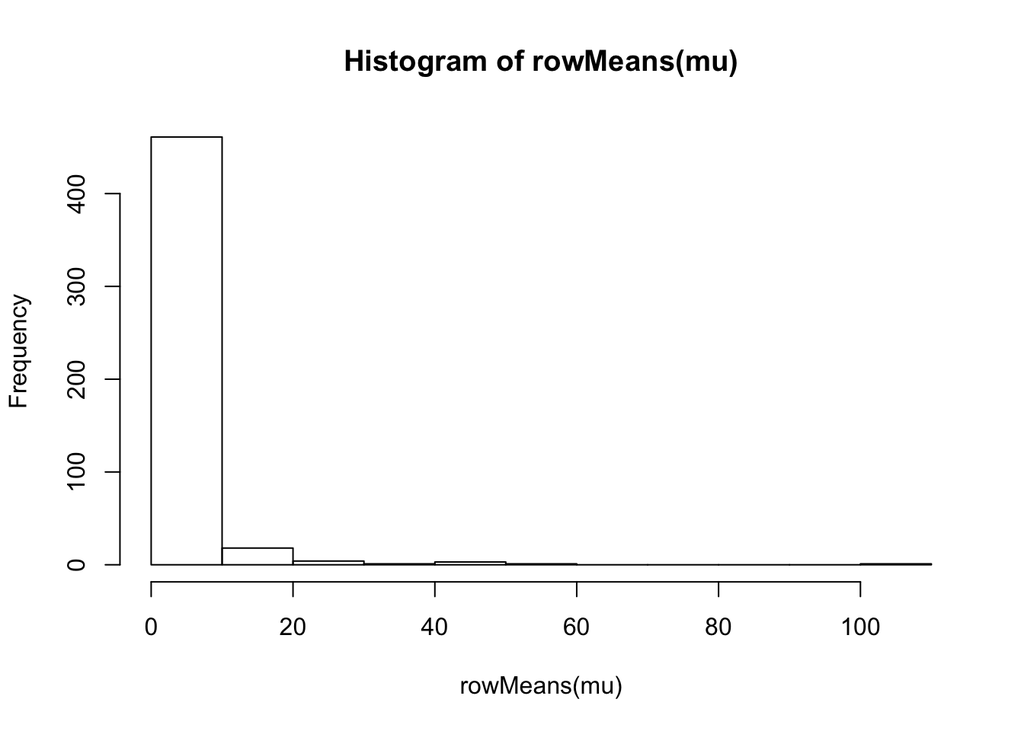

```r
      hist(rowMeans(mu))
```

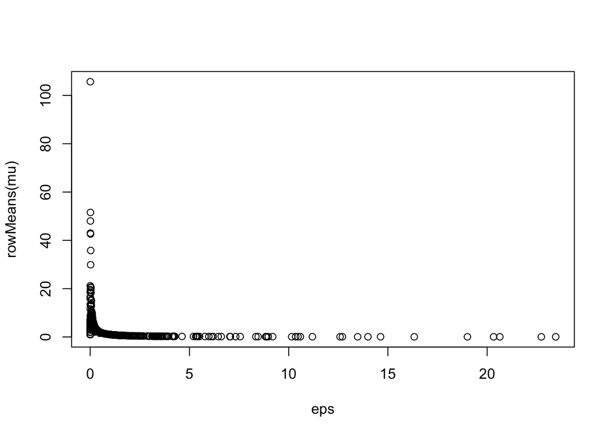

```r
      plot(eps, rowMeans(mu))
```

Now if we specify a prior probability that any user drops out of reddit $\rho$, we can then directly calculate the posterior distribution of the probability they dropped out from the monte-carlo samples above.

Let $t_i$ be the time between data collection and the most recent post for user $i$. This variable can be thought of the “censoring time”. Then, the posterior probability that a user quits given their true time between posts $p_i|mu_i$ is
$$p_i|mu_i = \frac{\rho} {e^{-mu*t}*(1-p) + p}$$

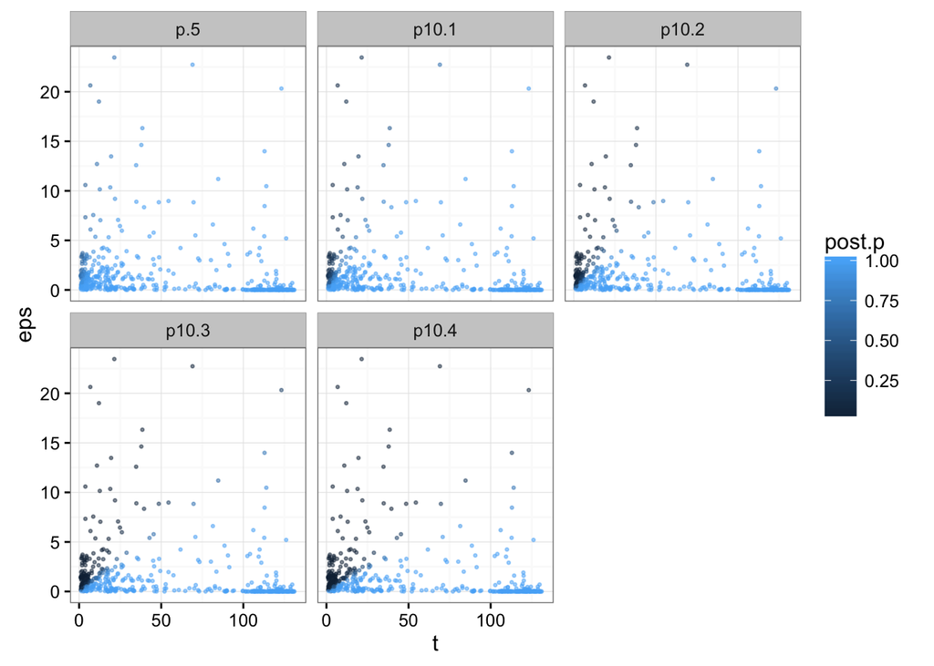

```r
### Calculate P(Q) from Mu and data
      prior.p = c(0.5, 10^-(1:4))
      make.p = function(mu,p) p / (exp(-mu*t)*(1-p) + p)
      post_p = sapply(prior.p, FUN = function(x) apply(mu, 2, make.p, p=x) %>% rowMeans)
      colnames(post_p) = c("p.5", paste0("p10.", 1:4))
      user.summary2 =
            cbind(user.summary, post_p) %>%
            select(-recent) %>%
            melt(id.vars = c("author", "n", "eps", "t"),
                 value.name = "post.p", variable.name = "prior.p")
      ggplot(user.summary2) +
            geom_point(aes(t, eps, color=post.p), size=0.5, alpha=0.5) +
            facet_wrap("prior.p") +
            theme_bw()
```

Finally, we can get the posterior distribution of the expected number of Reddit drop-outs.

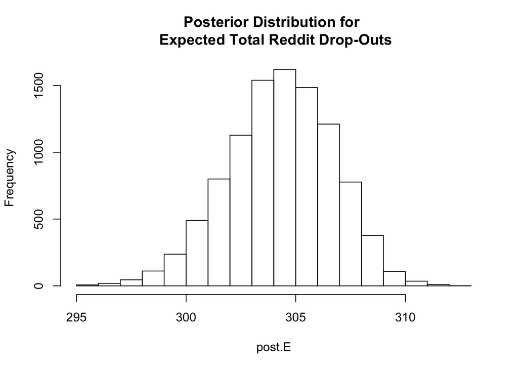

```r
### Now get overall credible interval for sum(Q)
      prior.p = 0.000001
      make.p = function(mu,p) p / (exp(-mu*t)*(1-p) + p)
      post.E = colSums(apply(mu, 2, make.p, p=prior.p))
      hist(post.E, main = "Posterior Distribution for \n Expected Total Reddit Drop-Outs")
```